# ML_final_project

# Integrating host response and unbiased microbe detection for precision sepsis diagnosis in critically ill adults

## Introduction

Sepsis is a major threat to public health. It causes nearly 20% of all deaths globally and contributes to one in every two to three hospital deaths in the United States (U.S.). Furthermore, it is the most expensive condition treated in the U.S., costing hospitals more than $38 billion dollars annually [1-3]. Sepsis mortality increases by 8% every hour that appropriate antibiotic therapy is delayed [4], making the rapid and accurate identification of the causative pathogen in bacterial sepsis critical to saving patients’ lives. Unfortunately, existing clinical infectious disease diagnostics are largely limited to antiquated, low-yield techniques [5, 6], and therefore, the causative pathogen is rarely identified. As a result, antibiotic treatment often remains empiric rather than pathogen-targeted, with clinical decision-making based on epidemiological information rather than individual patient data [7].  
Despite decades of research to improve infection diagnostics, current methods are limited by their reliance on a culturable pathogen, the kinetics of microorganism growth, and clinician-guided testing schema. With the advent of culture-independent methods, these challenges may be overcome. Metagenomic next generation sequencing (mNGS) is an unbiased approach to microbial identification, which can be applied directly to clinical samples [8]. This technique has been utilized for pathogen detection in complex clinical cases posing diagnostic dilemmas due to the failure of traditional diagnostics [9, 10]. mNGS also allows for the identification of host gene expression signatures that distinguish infectious and non-infectious insults [11, 12]. Sepsis, a “life-threatening organ dysfunction due to a dysregulated host response to infection,” [13] provides a well-suited opportunity to harness these strengths of mNGS and capture both host and microbe pathophysiology simultaneously.

## Methods

### Study design, clinical cohort and ethics statement

We conducted a prospective observational study of patients with acute critical illnesses admitted from the ED to the ICU. We studied patients who were enrolled at the University of California, San Francisco (UCSF) and Zuckerberg San Francisco General Hospital. The study was approved by the UCSF Institutional Review Board, which granted a waiver of initial consent for blood sampling. Informed consent was subsequently obtained from patients or their surrogates for continued study participation, as previously described.  
For this analysis, inclusion criteria were: (1) admission to the intensive care unit for mechanical ventilation for ARDS or airway protection, (2) age ≥ 18 years, (3) availability of while blood RNA-seq data with 106 protein-coding reads collected within five days of intubation and (4) availability of matched plasma samples to undergo DNA-seq. Exclusion criteria were those patients identified as outliers in the DESeq2 analysis using the variance stabilizing transformation (VST) and principle components analysis (PCA). Subject charts were reviewed by study authors (MA, CL, AL) to confirm a diagnosis of sepsis. Sepsis was adjudicated using the Sepsis-3 definition.

### Metagenomic sequencing

Whole blood and plasma were collected into Paxgene and standard tubes, and frozen within 2 hours. To evaluate host gene expression and detect microbes, metagenomic next generation sequencing RNA sequencing (RNA-seq) was performed on whole blood specimens and DNA-seq on plasma. RNA was extracted using the Qiagen RNEasy kit and normalized to 10ng total input per sample. Human cytosolic and mitochondrial ribosomal RNA and globin RNA was depleted using FastSelect (Qiagen). To control for background contamination, we included negative controls (water and HeLa cell RNA) as well as positive controls (spike-in RNA standards from the External RNA Controls Consortium (ERCC). RNA was then fragmented and underwent library preparation using the NEBNext Ultra II RNAseq Kit (New England Biolabs). DNA was extracted from 300uL of plasma using the Zymo Pathogen Magbead Kit before undergoing DNA-seq using the NEBNext Ultra II kit. Libraries underwent 146 nucleotide paired-end Illumina sequencing on an Illumina Novaseq 6000 instrument.

### Sepsis classifier using random forest

RNA sequencing reads that were used for differential gene expression analyses as outlined above were then used to perform sepsis classification using a random forest model. The dataset with only Group_1 and Group_4 was used with outliers identified by VST transformed gene count heatmaps and PCA analysis included. The dataset was split into training and validation sets at 70%/30%. The `caret` package was used to perform 10-fold cross-validation to fit the random forest model on the training set. The best random forest model that was identified by cross-validation was then used on the validation set to assess model performance. Model performance was assessed using area under the receiver operating characteristic curve (AUC) using the packages `pROC` and `Epi`. A confusion matrix also presented.

## Results

### Patient enrollment and sample collection

We conducted a prospective observational study of the EARLI cohort(refs) of critically ill adults admitted from the Emergency Department (ED) to the Intensive Care Unit (ICU). Patients were enrolled at two tertiary care hospitals in San Francisco, California under a research protocol approved by the University of California San Francisco Institutional Review Board (Methods). Following enrollment, whole blood and plasma were collected in the ED and stored at -80C prior to RNA and DNA extraction, respectively. RNA sequencing (RNA-seq) was carried out to assay the host response, and DNA-seq to identify microbes.  
Patients with sepsis were clinically adjudicated with blinding to mNGS results using the Sepsis-3 definition [17], and categorized into five subgroups of sepsis status: patients with sepsis due to clinically identified bloodstream infection Group_1 (SepisBldCx+), sepsis due to a microbiologically confirmed primary infection at a site other than the bloodstream Group_2 (SepsisOthCx+), suspected sepsis with negative clinical microbiologic testing Group_3 (Suspected), patients with no evidence of sepsis and a clear alternative explanation for their critical illness Group_4 (No-Sepsis), or patients of indeterminant status Group_5 (Indeterm). Patient demographics are presented in Table 1.

|  | 1_Sepsis+BldCx+ | 2_Sepsis+OtherCx+ | 3_Sepsis+Cx- | 4_NO_Sepsis | 5_Unclear | p | test |
| --- | --- | --- | --- | --- | --- | --- | --- |
| n | 64 | 67 | 68 | 94 | 33 |  |  |
| Age (mean (SD)) | 61.80 (15.33) | 67.52 (14.86) | 64.37 (15.29) | 63.70 (15.46) | 70.24 (12.32) | 0.049 |  |
| APACHEII (mean (SD)) | 33.05 (10.47) | 29.67 (7.33) | 32.19 (9.34) | 32.05 (9.90) | 31.06 (8.22) | 0.285 |  |
| APACHEIII (mean (SD)) | 66.42 (22.36) | 55.72 (16.34) | 64.74 (19.52) | 64.26 (18.58) | 63.18 (18.83) | 0.014 |  |
| TempMaxSAPS (mean (SD)) | 38.07 (1.11) | 37.53 (1.43) | 37.60 (1.16) | 36.92 (1.49) | 36.90 (1.43) | <0.001 |  |
| TempMinSAPS (mean (SD)) | 35.46 (2.09) | 35.04 (2.10) | 35.35 (1.60) | 34.49 (2.02) | 34.91 (2.10) | 0.020 |  |
| WBCMaxSAPS (mean (SD)) | 17.80 (12.13) | 15.92 (9.35) | 16.11 (9.29) | 16.44 (17.29) | 12.25 (5.92) | 0.352 |  |
| WBCMinSAPS (mean (SD)) | 12.51 (10.46) | 12.11 (6.47) | 12.01 (7.86) | 12.16 (14.66) | 10.13 (5.43) | 0.870 |  |
| HRMaxSAPS (mean (SD)) | 125.20 (24.33) | 109.49 (22.57) | 112.19 (24.75) | 106.18 (25.64) | 103.61 (21.58) | <0.001 |  |
| HRMinSAPS (mean (SD)) | 75.55 (23.71) | 66.39 (19.55) | 68.24 (20.41) | 58.76 (17.78) | 61.70 (16.48) | <0.001 |  |
| RRMaxSAPS (mean (SD)) | 35.27 (5.83) | 33.00 (8.63) | 35.03 (9.24) | 34.90 (11.57) | 34.48 (10.67) | 0.652 |  |
| RRMinSAPS (mean (SD)) | 14.89 (5.95) | 12.99 (4.02) | 13.60 (5.44) | 12.83 (5.73) | 12.18 (3.62) | 0.074 |  |
| SBPMaxSAPS (mean (SD)) | 155.52 (31.83) | 162.30 (32.09) | 155.82 (26.33) | 167.16 (33.63) | 168.52 (29.21) | 0.053 |  |
| SBPMinSAPS (mean (SD)) | 70.88 (15.30) | 76.96 (16.64) | 71.94 (14.22) | 76.82 (18.78) | 78.45 (16.58) | 0.047 |  |
| CreatinineMaxSAPS (mean (SD)) | 2.19 (1.88) | 2.12 (2.44) | 2.46 (2.92) | 2.68 (3.53) | 1.50 (1.12) | 0.258 |  |
| CreatinineMinSAPS (mean (SD)) | 1.75 (1.42) | 1.66 (1.80) | 1.91 (2.01) | 2.01 (2.35) | 1.34 (1.09) | 0.453 |  |
| PlateletsMinSAPS (mean (SD)) | 135.72 (115.16) | 175.85 (68.11) | 173.63 (108.09) | 177.30 (80.15) | 206.73 (96.79) | 0.007 |  |
| Gender (%) |  |  |  |  |  | 0.243 |  |
| Male | 45 ( 70.3) | 37 (55.2) | 38 ( 55.9) | 54 (57.4) | 14 ( 42.4) |  |  |
| Female | 19 ( 29.7) | 29 (43.3) | 29 ( 42.6) | 40 (42.6) | 19 ( 57.6) |  |  |
| Transgender | 0 ( 0.0) | 1 ( 1.5) | 1 ( 1.5) | 0 ( 0.0) | 0 ( 0.0) |  |  |
| Race (%) |  |  |  |  |  | 0.443 |  |
| Caucasian | 22 ( 34.4) | 28 (41.8) | 24 ( 35.3) | 37 (39.4) | 15 ( 45.5) |  |  |
| African American | 10 ( 15.6) | 11 (16.4) | 12 ( 17.6) | 18 (19.1) | 10 ( 30.3) |  |  |
| Asian | 18 ( 28.1) | 21 (31.3) | 23 ( 33.8) | 25 (26.6) | 6 ( 18.2) |  |  |
| Native American | 1 ( 1.6) | 0 ( 0.0) | 0 ( 0.0) | 0 ( 0.0) | 0 ( 0.0) |  |  |
| Other | 12 ( 18.8) | 5 ( 7.5) | 9 ( 13.2) | 14 (14.9) | 2 ( 6.1) |  |  |
| Unknown | 1 ( 1.6) | 2 ( 3.0) | 0 ( 0.0) | 0 ( 0.0) | 0 ( 0.0) |  |  |
| HospWithin30d = 1 (%) | 7 ( 10.9) | 7 (10.4) | 9 ( 13.2) | 17 (18.1) | 8 ( 24.2) | 0.282 |  |
| PNA_community = 1 (%) | 8 ( 12.5) | 9 (13.4) | 16 ( 23.5) | 5 ( 5.3) | 2 ( 6.1) | 0.009 |  |
| PNA_healthcare = 1 (%) | 7 ( 10.9) | 9 (13.4) | 10 ( 14.7) | 2 ( 2.1) | 5 ( 15.2) | 0.041 |  |
| COPD2 = 1 (%) | 10 ( 15.6) | 15 (22.4) | 12 ( 17.6) | 14 (14.9) | 14 ( 42.4) | 0.010 |  |
| CongestiveHeartFailure = 1 (%) | 12 ( 18.8) | 11 (16.4) | 16 ( 23.5) | 29 (30.9) | 16 ( 48.5) | 0.005 |  |
| CardiacArrest = 1 (%) | 5 ( 7.8) | 7 (10.4) | 4 ( 5.9) | 7 ( 7.4) | 3 ( 9.1) | 0.901 |  |
| PtSepsis = 1 (%) | 27 ( 42.2) | 31 (46.3) | 32 ( 47.1) | 5 ( 5.3) | 4 ( 12.1) | <0.001 |  |
| 28d death = 1 (%) | 23 ( 35.9) | 14 (20.9) | 28 ( 41.2) | 32 (34.0) | 12 ( 36.4) | 0.142 |  |
| 60d death = 1 (%) | 27 ( 42.2) | 16 (23.9) | 31 ( 45.6) | 34 (36.2) | 13 ( 39.4) | 0.094 |  |
| Hospital death = 1 (%) | 24 ( 37.5) | 15 (22.4) | 28 ( 41.2) | 30 (31.9) | 11 ( 33.3) | 0.192 |  |
| MechVent = 1 (%) | 49 ( 76.6) | 59 (88.1) | 60 ( 88.2) | 90 (95.7) | 31 ( 93.9) | 0.005 |  |
| SIRS_HR = 1 (%) | 58 ( 90.6) | 53 (79.1) | 57 ( 83.8) | 70 (74.5) | 22 ( 66.7) | 0.032 |  |
| SIRS_temp = 1 (%) | 51 ( 79.7) | 51 (76.1) | 54 ( 79.4) | 71 (75.5) | 24 ( 72.7) | 0.915 |  |
| SIRS_RR = 1 (%) | 64 (100.0) | 64 (95.5) | 68 (100.0) | 92 (97.9) | 33 (100.0) | 0.157 |  |
| SIRS_WBC = 1 (%) | 53 ( 82.8) | 45 (67.2) | 48 ( 70.6) | 54 (57.4) | 18 ( 54.5) | 0.008 |  |
| SIRS_total (%) |  |  |  |  |  | 0.014 |  |
| 1 | 0 ( 0.0) | 1 ( 1.5) | 0 ( 0.0) | 1 ( 1.1) | 1 ( 3.0) |  |  |
| 2 | 6 ( 9.4) | 11 (16.4) | 11 ( 16.2) | 22 (23.4) | 9 ( 27.3) |  |  |
| 3 | 18 ( 28.1) | 30 (44.8) | 23 ( 33.8) | 42 (44.7) | 14 ( 42.4) |  |  |
| 4 | 40 ( 62.5) | 25 (37.3) | 34 ( 50.0) | 29 (30.9) | 9 ( 27.3) |  |  |
| Intubated = 1 (%) | 49 ( 76.6) | 58 (86.6) | 62 ( 91.2) | 87 (92.6) | 31 ( 93.9) | 0.020 |  |
| OnPressorsSAPS = 1 (%) | 57 ( 89.1) | 49 (73.1) | 60 ( 88.2) | 61 (64.9) | 21 ( 63.6) | <0.001 |  |
| virusPresent = 1 (%) | 5 ( 7.8) | 22 (32.8) | 0 ( 0.0) | 0 ( 0.0) | 0 ( 0.0) | <0.001 |  |
| Immunocompromised = 1 (%) | 8 ( 12.5) | 5 ( 7.5) | 11 ( 16.2) | 6 ( 6.4) | 6 ( 18.2) | 0.157 |  |
| SOT = 1 (%) | 3 ( 4.7) | 0 ( 0.0) | 3 ( 4.4) | 1 ( 1.1) | 1 ( 3.0) | 0.296 |  |
| HTN = 1 (%) | 16 ( 25.0) | 31 (46.3) | 31 ( 45.6) | 44 (46.8) | 12 ( 36.4) | 0.045 |  |
| Cirrhosis = 1 (%) | 8 ( 12.5) | 4 ( 6.0) | 10 ( 14.7) | 6 ( 6.4) | 2 ( 6.1) | 0.247 |  |
| CKD = 1 (%) | 12 ( 18.8) | 15 (22.4) | 15 ( 22.1) | 29 (30.9) | 7 ( 21.2) | 0.438 |  |
| Malignancy = 1 (%) | 13 ( 20.3) | 14 (20.9) | 14 ( 20.6) | 20 (21.3) | 7 ( 21.2) | 1.000 |  |
| HIV = 1 (%) | 7 ( 10.9) | 4 ( 6.0) | 3 ( 4.4) | 7 ( 7.4) | 0 ( 0.0) | 0.281 |  |
| Diabetes = 1 (%) | 18 ( 28.1) | 22 (32.8) | 17 ( 25.0) | 31 (33.0) | 13 ( 39.4) | 0.599 |  |

### Host signature of blood culture positive sepsis

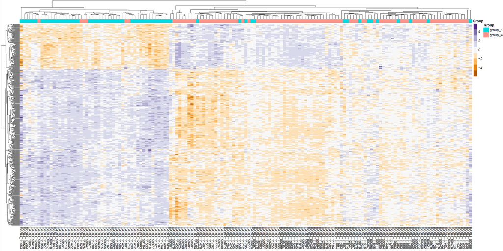

Figure 1

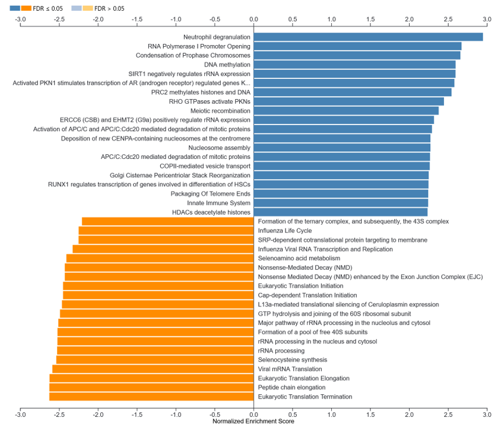

Figure 2

### Host transcriptional classifier for bloodstream infection-related sepsis

[figure not shown]

Figure 3

Table 2a - Confusion matrix: bolded labels are the true class

|  | group_1 | group_4 |
| --- | --- | --- |
| group_1 | 15 | 0 |
| group_4 | 3 | 27 |

Table 2b - Accuracy, kappa value, and 95% confidence interval of accuracy

|  | x |
| --- | --- |
| Accuracy | 0.9333333 |
| Kappa | 0.8571429 |
| AccuracyLower | 0.8173155 |
| AccuracyUpper | 0.9860349 |

Table 2c - Sensitivity, specificity, positive predictive value, and negative predictive value

|  | x |
| --- | --- |
| Sensitivity | 0.8333333 |
| Specificity | 1.0000000 |
| Pos Pred Value | 1.0000000 |
| Neg Pred Value | 0.9000000 |

## References

1. Rudd, K.E., et al., Global, regional, and national sepsis incidence and mortality, 1990-2017: analysis for the Global Burden of Disease Study. Lancet, 2020. 395(10219): p. 200-211.
2. Liu, V., et al., Hospital deaths in patients with sepsis from 2 independent cohorts. JAMA, 2014. 312(1): p. 90-2.
3. Liang, L.A., Moore B (IBM Watson Health), Soni A (AHRQ). National Inpatient Hospital Costs: The Most Expensive Conditions by Payer, 2017. HCUP Statistical Brief #261 2020 7/2/2020 [cited 2020 Sept. 2]; Available from: www.hcup-us.ahrq.gov/reports/statbriefs/sb261-Most-Expensive-Hospital-Conditions-2017.pdf.
4. Ferrer, R., et al., Empiric antibiotic treatment reduces mortality in severe sepsis and septic shock from the first hour: results from a guideline-based performance improvement program. Crit Care Med, 2014. 42(8): p. 1749-55.
5. Lamy, B., et al., What is the relevance of obtaining multiple blood samples for culture? A comprehensive model to optimize the strategy for diagnosing bacteremia. Clin Infect Dis, 2002. 35(7): p. 842-50.
6. Aronson, M.D. and D.H. Bor, Blood cultures. Ann Intern Med, 1987. 106(2): p. 246-53.
7. Timbrook, T.T., et al., The Effect of Molecular Rapid Diagnostic Testing on Clinical Outcomes in Bloodstream Infections: A Systematic Review and Meta-analysis. Clin Infect Dis, 2017. 64(1): p. 15-23.
8. Bibby, K., Metagenomic identification of viral pathogens. Trends Biotechnol, 2013. 31(5): p. 275-9.
9. Wilson, M.R., et al., Actionable diagnosis of neuroleptospirosis by next-generation sequencing. N Engl J Med, 2014. 370(25): p. 2408-17.
10. Wilson, M.R., et al., Diagnosing Balamuthia mandrillaris Encephalitis With Metagenomic Deep Sequencing. Ann Neurol, 2015. 78(5): p. 722-30.
11. Sweeney, T.E., H.R. Wong, and P. Khatri, Robust classification of bacterial and viral infections via integrated host gene expression diagnostics. Sci Transl Med, 2016. 8(346): p. 346ra91.
12. Tsalik, E.L., et al., Host gene expression classifiers diagnose acute respiratory illness etiology. Sci Transl Med, 2016. 8(322): p. 322ra11.
13. Singer, M., et al., The Third International Consensus Definitions for Sepsis and Septic Shock (Sepsis-3). JAMA, 2016. 315(8): p. 801-10.